# Project II

Nhung Nguyen

4/27/2022

```r
library(tidyverse)
library(lubridate)
```

## Overview

The data is from the project “How Department of Health (DOH) communicate about Covid-19 pandemic on 50 states and the Columbia District’s Facebook fan-pages?” The research groups collected about 10000 posts about Covid-19 Pandemic. The content of the post were taken into consideration under two perspectives: information related (eg. provide number of case, what risk factors relevant to the spread out of Covid virus), and call to action related (eg. mask up, stay at home, get test, or get vaccine).

Using different Health Communication theories, the research generating 20 variables on risk communication, calls to actions on testing, vaccination, and actions to prevent Covid, and sympathy to lost due to Covid. Furthermore, the research also explores on to what extent health efficacy at collective-individual level and negative-positive outcome connotation have been mentioned.

```r
DOH51states <- read_csv("datadoh.csv")
```

```
## * `` -> ...28
```

```
## Content, state
##
```

```r
DOH51states
```

```
## # A tibble: 9,869 × 28
##    Post_oldid Real_ID date       `\nContent`         COVID_Post RiskFactor_2_CTA
##         <dbl>   <dbl> <chr>      <chr>                    <dbl>            <dbl>
##  1          1    2069 9/22/2020  "California Govern…          1               88
##  2          2    2070 8/27/2020  "California Govern…          1               88
##  3          3    2071 12/29/2020 "California Govern…          1               88
##  4          4    2072 9/29/2020  "California Govern…          1               88
##  5          5    2073 10/6/2020  "California Govern…          1               88
##  6          6    2074 12/31/2020 "California Govern…          1               88
##  7          7     403 4/2/2020   "- Wash your hands…          1               88
##  8          8    5425 12/1/2020  "__COVID-19 UPDATE…          1               88
##  9          9    5842 12/20/2020 "__Need a COVID-19…          1               88
## 10         10    2075 3/5/2020   "\xe7Aqu\xd5 hay c…          1               88
## # … with 9,859 more rows, and 22 more variables: SocialDisparities_3_CTA <dbl>,
## #   Debunk_4_CTA <dbl>, UncertaintyReduction_5_CTA <dbl>, Testing_6_CTA <dbl>,
## #   Vaccine_7_CTA <dbl>, Mental_8_YesNo <dbl>, Emotion_9_Number <dbl>,
## #   Praise_10_Number <dbl>, Pop_11_Number <dbl>, Language_12_Number <dbl>,
## #   Action_13_CTA <dbl>, Positive_14a_Number <dbl>, Negative_14b_Number <dbl>,
## #   Individual_14c_Number <dbl>, Collective_14d_Number <dbl>,
## #   `State_ recode` <dbl>, year <dbl>, month <dbl>, day <dbl>, state <chr>, …
```

```r
colnames(DOH51states)
```

```
##  [1] "Post_oldid"                 "Real_ID"
##  [3] "date"                       "\nContent"
##  [5] "COVID_Post"                 "RiskFactor_2_CTA"
##  [7] "SocialDisparities_3_CTA"    "Debunk_4_CTA"
##  [9] "UncertaintyReduction_5_CTA" "Testing_6_CTA"
## [11] "Vaccine_7_CTA"              "Mental_8_YesNo"
## [13] "Emotion_9_Number"           "Praise_10_Number"
## [15] "Pop_11_Number"              "Language_12_Number"
## [17] "Action_13_CTA"              "Positive_14a_Number"
## [19] "Negative_14b_Number"        "Individual_14c_Number"
## [21] "Collective_14d_Number"      "State_ recode"
## [23] "year"                       "month"
## [25] "day"                        "state"
## [27] "cases"                      "...28"
```

- Because there are some variable name turned out to have some spelling mistake after the data file being converted from Excel, I need to rename to give them the more clean ones and also relocate to have the order of the variable that easy to follow.

```r
DOH51states_1 <-
  DOH51states %>%
  select(Post_oldid:state) %>%
  rename ("content" =  "\nContent") %>%
  relocate(state, .after = date)
DOH51states_1
```

```
## # A tibble: 9,869 × 26
##    Post_oldid Real_ID date       state content       COVID_Post RiskFactor_2_CTA
##         <dbl>   <dbl> <chr>      <chr> <chr>              <dbl>            <dbl>
##  1          1    2069 9/22/2020  CA    "California …          1               88
##  2          2    2070 8/27/2020  CA    "California …          1               88
##  3          3    2071 12/29/2020 CA    "California …          1               88
##  4          4    2072 9/29/2020  CA    "California …          1               88
##  5          5    2073 10/6/2020  CA    "California …          1               88
##  6          6    2074 12/31/2020 CA    "California …          1               88
##  7          7     403 4/2/2020   AK    "- Wash your…          1               88
##  8          8    5425 12/1/2020  NJ    "__COVID-19 …          1               88
##  9          9    5842 12/20/2020 RI    "__Need a CO…          1               88
## 10         10    2075 3/5/2020   CA    "\xe7Aqu\xd5…          1               88
## # … with 9,859 more rows, and 19 more variables: SocialDisparities_3_CTA <dbl>,
## #   Debunk_4_CTA <dbl>, UncertaintyReduction_5_CTA <dbl>, Testing_6_CTA <dbl>,
## #   Vaccine_7_CTA <dbl>, Mental_8_YesNo <dbl>, Emotion_9_Number <dbl>,
## #   Praise_10_Number <dbl>, Pop_11_Number <dbl>, Language_12_Number <dbl>,
## #   Action_13_CTA <dbl>, Positive_14a_Number <dbl>, Negative_14b_Number <dbl>,
## #   Individual_14c_Number <dbl>, Collective_14d_Number <dbl>,
## #   `State_ recode` <dbl>, year <dbl>, month <dbl>, day <dbl>
```

- Using `dim`, `map(sum(iss.na)`, and `colnames` to see the data dimensions, missing data, and column names.

```r
dim(DOH51states_1)
```

```
## [1] 9869   26
```

```r
invisible(map(DOH51states_1, ~sum(is.na(.))))
colnames(DOH51states_1)
```

```
##  [1] "Post_oldid"                 "Real_ID"
##  [3] "date"                       "state"
##  [5] "content"                    "COVID_Post"
##  [7] "RiskFactor_2_CTA"           "SocialDisparities_3_CTA"
##  [9] "Debunk_4_CTA"               "UncertaintyReduction_5_CTA"
## [11] "Testing_6_CTA"              "Vaccine_7_CTA"
## [13] "Mental_8_YesNo"             "Emotion_9_Number"
## [15] "Praise_10_Number"           "Pop_11_Number"
## [17] "Language_12_Number"         "Action_13_CTA"
## [19] "Positive_14a_Number"        "Negative_14b_Number"
## [21] "Individual_14c_Number"      "Collective_14d_Number"
## [23] "State_ recode"              "year"
## [25] "month"                      "day"
```

- The project also takes into consideration 10 different demographic variables such as governor’s political party, trifecta politic, and poverty rate of such states.

```r
DOHState_structure <- read_csv("DOHState_structure.csv")
DOHState_structure
```

```
## # A tibble: 51 × 10
##    State_Abb State_name  `State DOH links`     `State_ recode` Gov_poli Trifecta
##    <chr>     <chr>       <chr>                           <dbl>    <dbl>    <dbl>
##  1 AL        Alabama     https://www.facebook…               1        1        1
##  2 AK        Alaska      https://www.facebook…               2        1        3
##  3 AR        Arkansas    https://www.facebook…               3        1        1
##  4 AZ        Arizona     https://www.facebook…               4        1        1
##  5 CA        California  https://www.facebook…               5        2        2
##  6 CO        Colorado    https://www.facebook…               6        2        2
##  7 CT        Connecticut https://www.facebook…               7        2        2
##  8 DE        Delaware    https://www.facebook…               8        2        2
##  9 FL        Florida     https://www.facebook…               9        1        1
## 10 GA        Georgia     https://www.facebook…              10        1        1
## # … with 41 more rows, and 4 more variables: `White_\bpercent` <dbl>,
## #   minority_percent <dbl>, Poverty_percent <dbl>, ProspertiyRanking <dbl>
```

- Rename `State_Abb` to `state` to be compatible with the other data-frame on the variable `states`

```r
DOHState_structure1 <-
DOHState_structure %>%
  rename("state"= "State_Abb", "White_percent"= "White_\bpercent")
DOHState_structure1
```

```
## # A tibble: 51 × 10
##    state State_name  `State DOH links`         `State_ recode` Gov_poli Trifecta
##    <chr> <chr>       <chr>                               <dbl>    <dbl>    <dbl>
##  1 AL    Alabama     https://www.facebook.com…               1        1        1
##  2 AK    Alaska      https://www.facebook.com…               2        1        3
##  3 AR    Arkansas    https://www.facebook.com…               3        1        1
##  4 AZ    Arizona     https://www.facebook.com…               4        1        1
##  5 CA    California  https://www.facebook.com…               5        2        2
##  6 CO    Colorado    https://www.facebook.com…               6        2        2
##  7 CT    Connecticut https://www.facebook.com…               7        2        2
##  8 DE    Delaware    https://www.facebook.com…               8        2        2
##  9 FL    Florida     https://www.facebook.com…               9        1        1
## 10 GA    Georgia     https://www.facebook.com…              10        1        1
## # … with 41 more rows, and 4 more variables: White_percent <dbl>,
## #   minority_percent <dbl>, Poverty_percent <dbl>, ProspertiyRanking <dbl>
```

- Using `dim`, `map(sum(iss.na)`, and `colnames` to see the data dimensions, missing data, and column names.

```r
dim(DOHState_structure1 )
```

```
## [1] 51 10
```

```r
invisible(map(DOHState_structure1 , ~sum(is.na(.))))
colnames(DOHState_structure1 )
```

```
##  [1] "state"             "State_name"        "State DOH links"
##  [4] "State_ recode"     "Gov_poli"          "Trifecta"
##  [7] "White_percent"     "minority_percent"  "Poverty_percent"
## [10] "ProspertiyRanking"
```

The data analysis project for PSYC800 using this data will focus on the below main tasks:

## Data wrangling

### Joining related data and Visualization

- First of all, I joined the two data-frames using `left_join`, by this, I retained all values in the `DOH51states_1` and joint the values in the `DOHState_structure1` datasets by comparing the values in `state` variables, which can be found in both dataset.

```r
data51states1 <-
DOH51states_1 %>%
left_join(DOHState_structure1, by = "state")
data51states1
```

```
## # A tibble: 9,869 × 35
##    Post_oldid Real_ID date       state content       COVID_Post RiskFactor_2_CTA
##         <dbl>   <dbl> <chr>      <chr> <chr>              <dbl>            <dbl>
##  1          1    2069 9/22/2020  CA    "California …          1               88
##  2          2    2070 8/27/2020  CA    "California …          1               88
##  3          3    2071 12/29/2020 CA    "California …          1               88
##  4          4    2072 9/29/2020  CA    "California …          1               88
##  5          5    2073 10/6/2020  CA    "California …          1               88
##  6          6    2074 12/31/2020 CA    "California …          1               88
##  7          7     403 4/2/2020   AK    "- Wash your…          1               88
##  8          8    5425 12/1/2020  NJ    "__COVID-19 …          1               88
##  9          9    5842 12/20/2020 RI    "__Need a CO…          1               88
## 10         10    2075 3/5/2020   CA    "\xe7Aqu\xd5…          1               88
## # … with 9,859 more rows, and 28 more variables: SocialDisparities_3_CTA <dbl>,
## #   Debunk_4_CTA <dbl>, UncertaintyReduction_5_CTA <dbl>, Testing_6_CTA <dbl>,
## #   Vaccine_7_CTA <dbl>, Mental_8_YesNo <dbl>, Emotion_9_Number <dbl>,
## #   Praise_10_Number <dbl>, Pop_11_Number <dbl>, Language_12_Number <dbl>,
## #   Action_13_CTA <dbl>, Positive_14a_Number <dbl>, Negative_14b_Number <dbl>,
## #   Individual_14c_Number <dbl>, Collective_14d_Number <dbl>,
## #   `State_ recode.x` <dbl>, year <dbl>, month <dbl>, day <dbl>, …
```

- Using `dim`, `map(sum(iss.na)`, and `colnames` to see the data dimensions, missing data, and column names.

```r
dim(data51states1)
```

```
## [1] 9869   35
```

```r
colnames(data51states1)
```

```
##  [1] "Post_oldid"                 "Real_ID"
##  [3] "date"                       "state"
##  [5] "content"                    "COVID_Post"
##  [7] "RiskFactor_2_CTA"           "SocialDisparities_3_CTA"
##  [9] "Debunk_4_CTA"               "UncertaintyReduction_5_CTA"
## [11] "Testing_6_CTA"              "Vaccine_7_CTA"
## [13] "Mental_8_YesNo"             "Emotion_9_Number"
## [15] "Praise_10_Number"           "Pop_11_Number"
## [17] "Language_12_Number"         "Action_13_CTA"
## [19] "Positive_14a_Number"        "Negative_14b_Number"
## [21] "Individual_14c_Number"      "Collective_14d_Number"
## [23] "State_ recode.x"            "year"
## [25] "month"                      "day"
## [27] "State_name"                 "State DOH links"
## [29] "State_ recode.y"            "Gov_poli"
## [31] "Trifecta"                   "White_percent"
## [33] "minority_percent"           "Poverty_percent"
## [35] "ProspertiyRanking"
```

```r
invisible(map(data51states1, ~sum(is.na(.))))
```

- Because there are about 30 variables in the project, I cannot perform analysis for all of them. I decided to used some variables to showcase what I have learnt from the course. Therefore, I used `select` to choose the some variables to analyze

```r
data51states2<-
data51states1 %>%
  select(Real_ID, month, state,
         Gov_poli, Trifecta,
         minority_percent,
         ProspertiyRanking,
         Mental_8_YesNo,
         Pop_11_Number,
         RiskFactor_2_CTA,
         SocialDisparities_3_CTA,
         Positive_14a_Number
       )
data51states2
```

```
## # A tibble: 9,869 × 12
##    Real_ID month state Gov_poli Trifecta minority_percent ProspertiyRanking
##      <dbl> <dbl> <chr>    <dbl>    <dbl>            <dbl>             <dbl>
##  1    2069     9 CA           2        2             63.5                25
##  2    2070     8 CA           2        2             63.5                25
##  3    2071    12 CA           2        2             63.5                25
##  4    2072     9 CA           2        2             63.5                25
##  5    2073    10 CA           2        2             63.5                25
##  6    2074    12 CA           2        2             63.5                25
##  7     403     4 AK           1        3             39.8                39
##  8    5425    12 NJ           2        2             45.4                12
##  9    5842    12 RI           2        1             28.6                18
## 10    2075     3 CA           2        2             63.5                25
## # … with 9,859 more rows, and 5 more variables: Mental_8_YesNo <dbl>,
## #   Pop_11_Number <dbl>, RiskFactor_2_CTA <dbl>, SocialDisparities_3_CTA <dbl>,
## #   Positive_14a_Number <dbl>
```

`Real_ID`“`: the unique number assigned for each post to retrỉeve if any information seems not right` `month`: the month that the posts were posted `state`: abbreviation of the states’ names

**Independent variables**

`Gov_poli`: State’ governor’s political party

`Trifecta`: State government Trifecta is a term to describe single-party government, when one political party holds the governorship and majorities in both chambers of the state legislature

`minority_percent`: Percentage of minority people in state’s population

`ProspertiyRanking`: Rank of the state’s prosperity

**Dependent variables**

`Mental_8_YesNo`: Whether or not the posts mentioned mental health issues.

`Pop_11_Number`: Numbers of vulnerable groups (eg. minority people, senior people, ppl with pre health conditions) have been mentions in the posts.

`RiskFactor_2_CTA`: Call-to-actions related to Risk Factors

`SocialDisparities_3_CTA`: Call-to-actions on Social Disparities

`Positive_14a_Number`: Number of positive outcomes generated in the posts.

- First of all, I wanted to plot a chart explaining the relationship between States’ “Percentage of minority people” and “Number of groups of vulnerable populations” were mentioned in the posts.

```r
library(ggthemes)
```

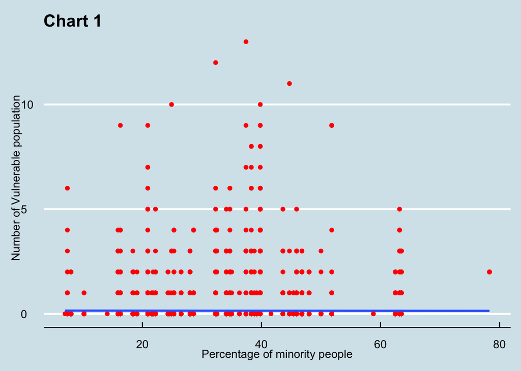

```r
p1 <-
data51states2 %>%
      drop_na(minority_percent) %>%
      drop_na(Pop_11_Number) %>%
      ggplot(aes(x= minority_percent, y= Pop_11_Number)) +
      geom_point(color = "red") +
      scale_color_continuous(
      type = "viridis",
      limits = c(0,20),
      breaks = c(0, 10, 20, 30, 40, 50)) +
      geom_smooth(method= "lm") +
      labs(title = "Chart 1",
           x = "Percentage of minority people",
           y = "Number of Vulnerable population") +
     theme_economist()
p1
```

- Second, for `SocialDisparities_3_CTA`, I want to exclude value 88, so that I only plot chart of the post that mentioned social disparities and provide “Call to action” messages.

```r
library(purrr)
library(magrittr)
data51states2a<- filter(data51states2, SocialDisparities_3_CTA != 88)
data51states2a
```

```
## # A tibble: 176 × 12
##    Real_ID month state Gov_poli Trifecta minority_percent ProspertiyRanking
##      <dbl> <dbl> <chr>    <dbl>    <dbl>            <dbl>             <dbl>
##  1    5458    12 NY           2        2             44.7                15
##  2    5459    12 NY           2        2             44.7                15
##  3    9282     1 DC           2        2             62.5                 8
##  4    9283    12 DC           2        2             62.5                 8
##  5    9284    12 DC           2        2             62.5                 8
##  6    9285    10 DC           2        2             62.5                 8
##  7    9286     4 DC           2        2             62.5                 8
##  8     418    11 AK           1        3             39.8                39
##  9    1654    11 AZ           1        1             45.9                40
## 10    5188    12 MN           2        3             20.9                 3
## # … with 166 more rows, and 5 more variables: Mental_8_YesNo <dbl>,
## #   Pop_11_Number <dbl>, RiskFactor_2_CTA <dbl>, SocialDisparities_3_CTA <dbl>,
## #   Positive_14a_Number <dbl>
```

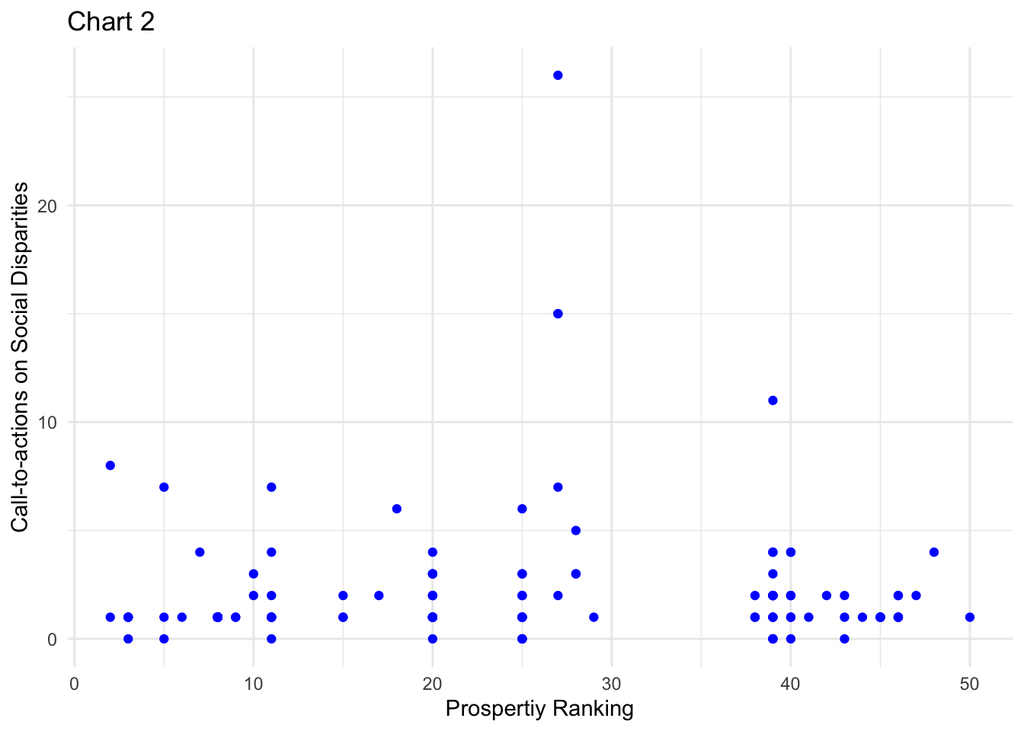

```r
p2 <-
data51states2a %>%
       drop_na(ProspertiyRanking) %>%
       drop_na(SocialDisparities_3_CTA) %>%
  ggplot(aes(x= ProspertiyRanking, y = SocialDisparities_3_CTA)) +
  geom_point(color = "blue", fill = "pink") +
   labs(title = "Chart 2",
           x = "Prospertiy Ranking",
           y = "Call-to-actions on Social Disparities") +
  theme_minimal()
p2
```

**Interpretation**: Almost all of posts mentioned below 5 call-to-actions, some of them mentioned 5-10 call-to-actions related to social disparities, only a few of them mentioned above 10 call-to-actions. There are one post mentioned 26 call-to-actions. States with prosperity ranking from 20th to 30, mentioned most of call-to-actions, while states ranked at 10- 20th and 30-40th mentioned fewer call-to-actions.

### Grouping, Summarizing and Visualization

```r
data51states3 <-
data51states2 %>%
  mutate (Gov_poli = as.factor(Gov_poli)) %>%
  group_by(month, state, Gov_poli) %>%
  summarize(Positive_14a_Number =  n(),
          ) %>%
ungroup()
data51states3
```

```
## # A tibble: 256 × 4
##    month state Gov_poli Positive_14a_Number
##    <dbl> <chr> <fct>                  <int>
##  1     1 AK    1                          1
##  2     1 AL    1                          7
##  3     1 AR    1                          2
##  4     1 AZ    1                         10
##  5     1 CA    2                          6
##  6     1 CT    2                          5
##  7     1 DC    2                         30
##  8     1 DE    2                          2
##  9     1 GA    1                          1
## 10     1 KY    2                          7
## # … with 246 more rows
```

- I then, thirth , plot the chart to explain the frequency of `Govenors' political parties` by `state` and States’ `Govenors' political parties`

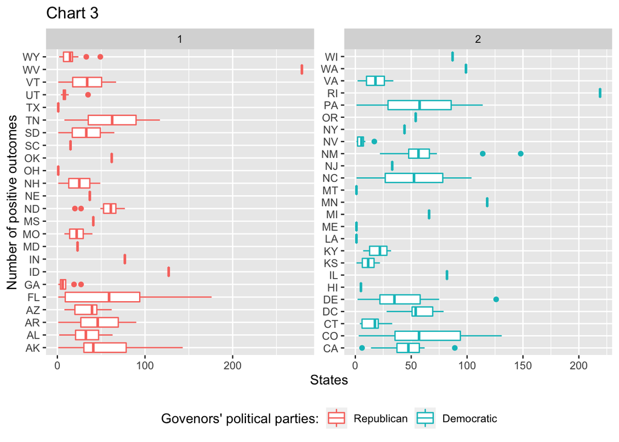

```r
p3 <-
  data51states3 %>%
   drop_na(Positive_14a_Number) %>%
   drop_na(Gov_poli) %>%
   ggplot(aes(x = Positive_14a_Number, y = state, color = Gov_poli), na.rm =TRUE) +
   geom_boxplot() +
   labs(title = "Chart 3", x = "States", y = "Number of positive outcomes") +
   scale_colour_discrete(name="Govenors' political parties:",
                      labels=c("Republican", "Democratic")) +
                      theme(legend.position = "bottom") +
   facet_wrap(~Gov_poli, scales = "free")
p3
```

- I am also interested in summarizing the number of `Call-to-actions related to Risk Factors` in the data by sate month.

```r
data51states4 <-
    data51states2 %>%
    group_by(state, month) %>%
    summarize(sRiskFactor_CTA =  sum(RiskFactor_2_CTA)) %>%
    mutate (month = as.factor(month)) %>%
    mutate (state = as.factor(state))
    data51states4
```

```
## # A tibble: 256 × 3
## # Groups:   state [51]
##    state month sRiskFactor_CTA
##    <fct> <fct>           <dbl>
##  1 AK    1                  88
##  2 AK    2                 264
##  3 AK    3                4820
##  4 AK    4                4843
##  5 AK    5                2750
##  6 AK    6                1533
##  7 AK    7                2766
##  8 AK    8                3467
##  9 AK    9                2502
## 10 AK    10               8047
## # … with 246 more rows
```

Then, forth, I plot the chart showing number of `Call-to-actions related to Risk Factors`in each state per month

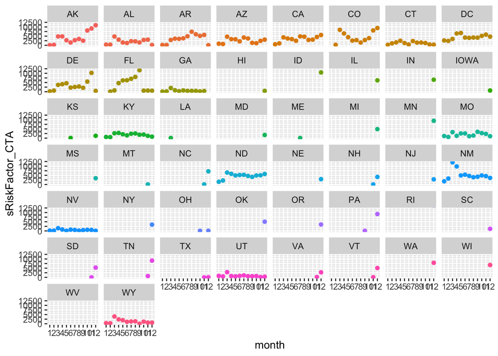

```r
p4 <-
data51states4 %>%
    drop_na(sRiskFactor_CTA) %>%
   drop_na(state) %>%
  drop_na(month) %>%
   ggplot(aes(x = month, y = sRiskFactor_CTA, color = factor(state)), na.rm =TRUE) +
  geom_point() +
  geom_smooth() +
  coord_cartesian(ylim = c(0, 12000)) +
  facet_wrap(~state) +
  theme(legend.position="none")

p4
```

- Finally, I was also curious to see how many posts mentioned the mental health related to the Covid pandemic. I ran a `summary` to see how many posts mentioned mental health issues in total.

```r
data51states2 %>%
  drop_na(Mental_8_YesNo) %>%
  group_by(Mental_8_YesNo) %>%
  summarize(nMental_8_YesNo = n())
```

```
## # A tibble: 2 × 2
##   Mental_8_YesNo nMental_8_YesNo
##            <dbl>           <int>
## 1              0            9686
## 2              1             181
```

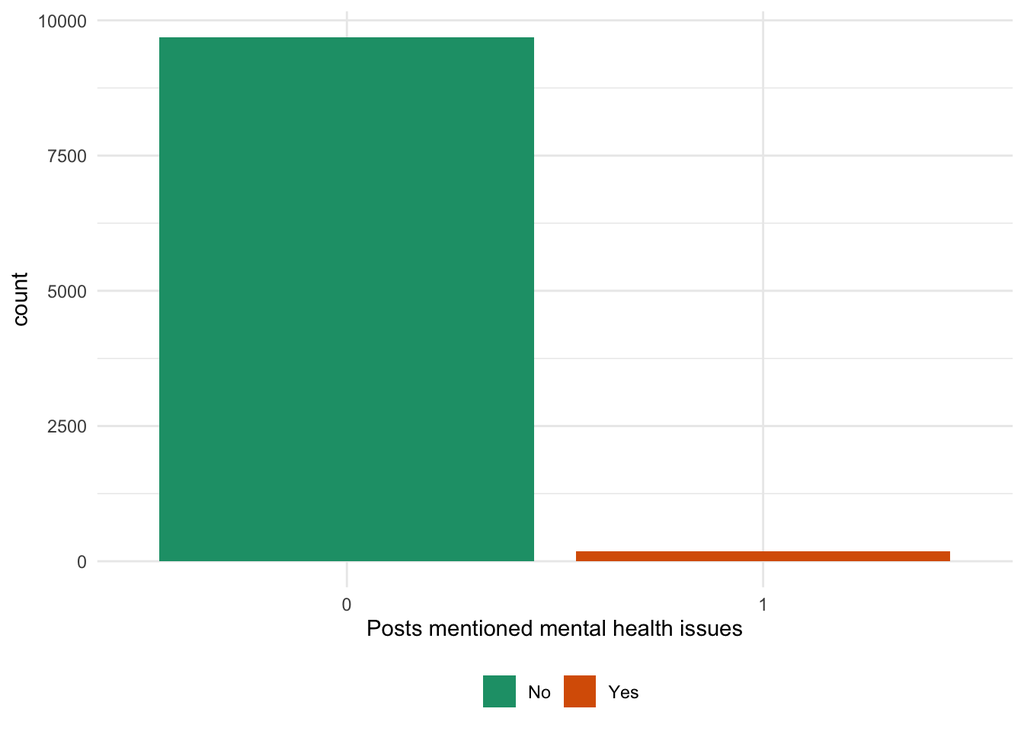

```r
p5 <-
  data51states2 %>%
  drop_na(Mental_8_YesNo) %>%
   mutate(Mental_8_YesNo = factor(Mental_8_YesNo)) %>%
  ggplot(aes(x= Mental_8_YesNo, fill = Mental_8_YesNo)) +
  geom_bar() +
  theme_minimal() +
  theme(legend.position="bottom", legend.title = element_blank()) +
        scale_fill_brewer(palette="Dark2", labels = c("No", "Yes")) +
        scale_x_discrete(name ="Posts mentioned mental health issues")

  p5
```

**Interpretation**: There are about 181 posts that mentioned mental health issues during the year 2020 out of 9867 posts, it seems that mental health issues have not been paid adequate attention by the States’ Health Department during the outbeak of the Covid 19 pandemic in the USA.

```r
library(patchwork)
```

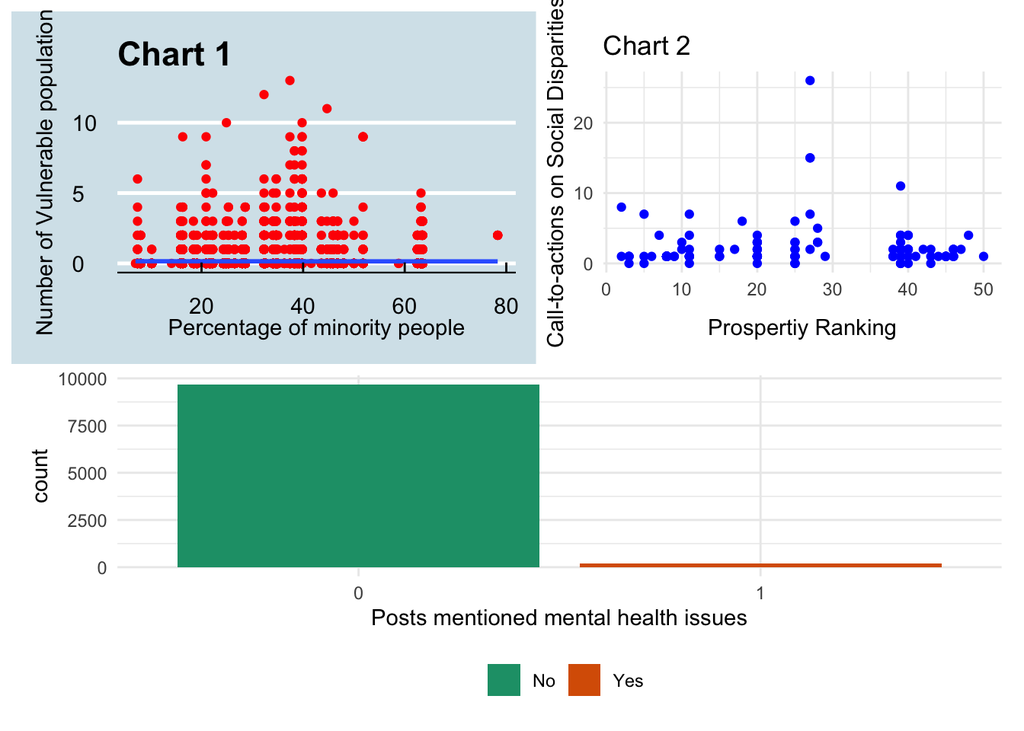

```r
(p1|p2)/p5
```

## Text mining

- I tried to scratch some surface of the data text such as word frequency and dictionary. First, I recalled the original `DOH51states_1`, changed select two variables `Post_oldid` and `content`. I then changed the variable `Post_oldid` type from double to integer and changed its name to `ID`.

```r
dohtext <-
DOH51states_1 %>%
  select(Post_oldid, content) %>%
  mutate(Post_oldid = as.integer(Post_oldid)) %>%
  rename ("ID" = "Post_oldid")
dohtext
```

```
## # A tibble: 9,869 × 2
##       ID content
##    <int> <chr>
##  1     1 "California Governor was live.\n21 September at 07:53 \x87\nGovernor G…
##  2     2 "California Governor was live.\n26 August at 07:44 \x87\nGovernor Gavi…
##  3     3 "California Governor was live.\n28 December at 09:16 \x87\nGovernor Ga…
##  4     4 "California Governor was live.\n28 September at 08:03 \x87\nGovernor G…
##  5     5 "California Governor was live.\n5 October at 08:12 \x87\nGovernor Gavi…
##  6     6 "California Governor was live.\nYesterday at 08:49 \x87\nWe will be go…
##  7     7 "- Wash your hands often with soap and water for 20 seconds.\n- Clean …
##  8     8 "__COVID-19 UPDATE__ EFFECTIVE:\n1__ 6am, December 5-January 2, 2021, …
##  9     9 "__Need a COVID-19 test? Everyone in RI can sign up for a free test at…
## 10    10 "\xe7Aqu\xd5 hay cuatro maneras en las que puedes ayudar a prevenir el…
## # … with 9,859 more rows
```

```r
library(tidytext)
library(tidyr)
```

- Using `unnest_tokens` to put each word in a row.

```r
dohtext1 <-
dohtext %>%
      unnest_tokens(word, content)
dohtext1
```

```
## # A tibble: 590,989 × 2
##       ID word
##    <int> <chr>
##  1     1 california
##  2     1 governor
##  3     1 was
##  4     1 live
##  5     1 21
##  6     1 september
##  7     1 at
##  8     1 07
##  9     1 53
## 10     1 governor
## # … with 590,979 more rows
```

- Often in text analysis, we will want to remove stop words, which are We can remove stop words words that are not useful for an analysis, typically extremely common words such as “the,” “of,” “to,” and so forth in English. We can remove stop words (kept in the tidy‐text dataset stop_words) with an `anti_join()`.

```r
dohtext2 <-
dohtext1 %>%
  count(word, sort = TRUE) %>%
   anti_join(stop_words)
dohtext2
```

```
## # A tibble: 23,499 × 2
##    word            n
##    <chr>       <int>
##  1 covid       10253
##  2 19          10210
##  3 https        3423
##  4 health       3283
##  5 covid19      3125
##  6 testing      2297
##  7 de           2048
##  8 total        2012
##  9 coronavirus  2002
## 10 information  1857
## # … with 23,489 more rows
```

- I chose the words which were used over 1000 times and `reorder` them using the order of numbers of times the word were occurred.

```r
dohtext3 <-
dohtext2 %>%
  filter(n > 1000) %>%
  mutate(word = reorder(word, n))
dohtext3
```

```
## # A tibble: 34 × 2
##    word            n
##    <fct>       <int>
##  1 covid       10253
##  2 19          10210
##  3 https        3423
##  4 health       3283
##  5 covid19      3125
##  6 testing      2297
##  7 de           2048
##  8 total        2012
##  9 coronavirus  2002
## 10 information  1857
## # … with 24 more rows
```

- I then tried to remove the left over stop-words that are not useful for analysis.

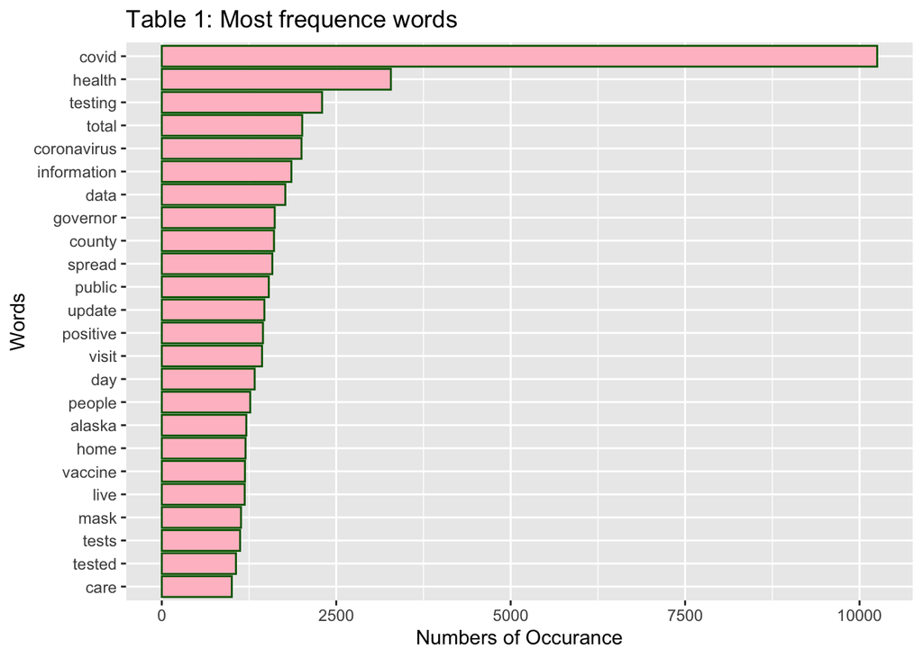

```r
remove.list = paste(c("19" , "https",  "de" , "__" , "1" ,  "2", "100,000", "http"),
                    collapse = '|')

dohtext3 %>%
  filter(!str_detect(word, remove.list)) %>%
  ggplot(aes(word, n)) +
  geom_col( color = "dark green", fill = "pink") +
  labs(title = "Table 1: Most frequence words", x = "Words", y = "Numbers of Occurance") +
  coord_flip()
```

**Interpretation**: The chart showed the most frequent words that have been used in the corpus of 590, 989 words in 9867 posts that related to the Covid-19 pandemic and genated by Department of Health in 50 states and 1 District in the US. Covid itself has been used over 10000 times, following with the main themes of heath, testing, information, data, governor, county, and so on.

## Retrospectives

It is very nice to use the tool that I’ve learnt the last three month in exploring the real data pf a project that I am actually working on. I have also realized that it is nice to have some freedom to explore the data the way I wanted. However, I also found that there are two type of skills that I need to learn in the future: (1) using R for different statistical test and (2) using R for text mining. These are the two necessary skills for me to be better off as a communication researcher who want to work more on big data and text data using R language.